# Dummy Variables and Probability Models Assignment

Predicting High-Price Homes in Ames, Iowa - DUE on November 21

Author

Mina Tavakkoli Jouybari - MBAN5520 Statistics

Published

November 19, 2025

The submission instructions are the same as in Assignment 1.

# Introduction

## Assignment Objectives

In this assignment, you will apply dummy variable encoding and probability models to predict high-price homes using the Ames Housing dataset. You will:

- Create and interpret dummy variables for categorical predictors
- Understand interaction effects between variables
- Build and compare Linear Probability Models (LPM) and Logistic Regression
- Calculate and interpret marginal effects (AME vs MEM)
- Evaluate classification performance using confusion matrices
- Select optimal thresholds based on business objectives

## Dataset: Ames Housing Data

The Ames Housing dataset contains residential home sales in Ames, Iowa. For this assignment, we will predict which homes sell for “high prices” (above the 95th percentile).

# Part A: Data Loading and Binary Outcome Creation

## Load and Prepare Data

```r
# Load the dataset
housing <- read.csv("AmesHousing.csv")

# Calculate 95th percentile of sale price
price_95 <- quantile(housing$SalePrice, 0.95)

# Create binary outcome: HighPrice (1 if above 95th percentile, 0 otherwise)
housing_clean <- housing %>%
  mutate(
    HighPrice = ifelse(SalePrice > price_95, 1, 0)
  ) %>%
  # Select relevant variables
  select(
    HighPrice,
    SalePrice,
    Gr.Liv.Area,
    Overall.Qual,
    Year.Built,
    Neighborhood,
    Central.Air,
    Garage.Type,
    Garage.Cars,
    Full.Bath,
    Bedroom.AbvGr
  ) %>%
  # Remove missing values
  drop_na()

# Display dimensions
dim(housing_clean)
```

```
[1] 2772   11
```

```r
# Show first few rows
head(housing_clean, 10) %>%
  kable(caption = "First 10 Observations",
        digits = 0) %>%
  kable_styling(bootstrap_options = c("striped", "hover"))
```

First 10 Observations

| HighPrice | SalePrice | Gr.Liv.Area | Overall.Qual | Year.Built | Neighborhood | Central.Air | Garage.Type | Garage.Cars | Full.Bath | Bedroom.AbvGr |
| --- | --- | --- | --- | --- | --- | --- | --- | --- | --- | --- |
| 0 | 215000 | 1656 | 6 | 1960 | NAmes | Y | Attchd | 2 | 1 | 3 |
| 0 | 105000 | 896 | 5 | 1961 | NAmes | Y | Attchd | 1 | 1 | 2 |
| 0 | 172000 | 1329 | 6 | 1958 | NAmes | Y | Attchd | 1 | 1 | 3 |
| 0 | 244000 | 2110 | 7 | 1968 | NAmes | Y | Attchd | 2 | 2 | 3 |
| 0 | 189900 | 1629 | 5 | 1997 | Gilbert | Y | Attchd | 2 | 2 | 3 |
| 0 | 195500 | 1604 | 6 | 1998 | Gilbert | Y | Attchd | 2 | 2 | 3 |
| 0 | 213500 | 1338 | 8 | 2001 | StoneBr | Y | Attchd | 2 | 2 | 2 |
| 0 | 191500 | 1280 | 8 | 1992 | StoneBr | Y | Attchd | 2 | 2 | 2 |
| 0 | 236500 | 1616 | 8 | 1995 | StoneBr | Y | Attchd | 2 | 2 | 2 |
| 0 | 189000 | 1804 | 7 | 1999 | Gilbert | Y | Attchd | 2 | 2 | 3 |

### **Question 1**: What is the 95th percentile threshold for high prices? What percentage of homes are classified as “high price”?

**Answer:** [The 95th percentile cutoff for high-price homes is $335,000. In other words, any home that sold for more than $335,000 is considered a high-price property. Out of 2,772 homes in the dataset, 144 fall above this cutoff, which means about 5.2% of all homes are classified as high price.]

```r
# Calculate statistics about the binary outcome

# 95th percentile cutoff
price_95
```

```
   95%
335000
```

```r
# Total homes
n_total <- nrow(housing_clean)

# Number of high-price homes
n_high <- sum(housing_clean$HighPrice == 1)

# Percentage high price
percent_high <- n_high / n_total * 100

# Print results
n_total
```

```
[1] 2772
```

```r
n_high
```

```
[1] 144
```

```r
percent_high
```

```
[1] 5.194805
```

### **Question 2**: Why might we want to predict high-price homes rather than predict the exact sale price?

**Answer:** [We predict high price homes instead of the exact sale price because it is more useful and more stable for real-estate decisions. Predicting a simple 0 or 1 (high-price or not) is easier and more reliable than trying to guess the exact dollar amount. For real estate agents, knowing whether a home belongs to the top 5% of prices helps them focus their marketing, choose the right buyers, and manage their time and resources better. Exact prices can be very unpredictable, but predicting whether a home is “high-price” gives a cleaner, more practical signal for business purposes.]

# Part B: Dummy Variable Models

## Single Dummy Variable: Central Air

Central Air is a binary variable (Y/N). Let’s create a dummy variable and model its effect on high-price probability.

```r
# Create dummy variable for Central Air (Y=1, N=0)
housing_clean <- housing_clean %>%
  mutate(
    CentralAir_Dummy = ifelse(Central.Air == "Y", 1, 0)
  )

# Fit linear regression with dummy variable
model_air <- lm(HighPrice ~ CentralAir_Dummy, data = housing_clean)
summary(model_air)
```

```
Call:
lm(formula = HighPrice ~ CentralAir_Dummy, data = housing_clean)

Residuals:
     Min       1Q   Median       3Q      Max
-0.05467 -0.05467 -0.05467 -0.05467  0.94533

Coefficients:
                  Estimate Std. Error t value Pr(>|t|)
(Intercept)      4.863e-15  1.887e-02   0.000  1.00000
CentralAir_Dummy 5.467e-02  1.936e-02   2.824  0.00478 **
---
Signif. codes:  0 '***' 0.001 '**' 0.01 '*' 0.05 '.' 0.1 ' ' 1

Residual standard error: 0.2217 on 2770 degrees of freedom
Multiple R-squared:  0.002871,  Adjusted R-squared:  0.002511
F-statistic: 7.975 on 1 and 2770 DF,  p-value: 0.004777
```

### **Question 3**: Interpret the coefficient for CentralAir_Dummy. What does it tell us about houses with central air?

**Answer:** [The coefficient for CentralAir_Dummy is 0.05467, which means that homes with central air are about 5.5% more likely to be high-price than homes without central air. In simple words, having central air makes a house more likely to fall into the luxury or high-price group. The p-value is very small (0.0048), so this difference is real and statistically meaningful, not just random.]

```r
# Verify by calculating group means
# Mean high-price rate for houses with and without central air

housing_clean %>%
  group_by(Central.Air) %>%
  summarize(mean_highprice = mean(HighPrice))
```

```
# A tibble: 2 × 2
  Central.Air mean_highprice
  <chr>                <dbl>
1 N                   0
2 Y                   0.0547
```

### **Question 4**: Verify that the coefficient equals the difference in mean HighPrice between the two groups.

**Answer:** [To verify the coefficient, I calculated the average HighPrice separately for homes with and without central air: Mean HighPrice (No central air) = 0.00000 Mean HighPrice (Yes central air) = 0.0546697

Calculation: 0.0546697 − 0.00000= 0.0546697

The regression coefficient for CentralAir_Dummy is also 0.05467, so the difference in group means matches the coefficient exactly, as expected for a dummy variable model.]

## Multiple Category Dummy Variables: Neighborhood

Neighborhood has many categories. We need to create k-1 dummy variables.

```r
# Check how many neighborhoods we have
table(housing_clean$Neighborhood)
```

```
Blmngtn Blueste  BrDale BrkSide ClearCr CollgCr Crawfor Edwards Gilbert  Greens
     28      10      29      96      43     265     103     157     165       8
GrnHill  IDOTRR Landmrk MeadowV Mitchel   NAmes NoRidge NPkVill NridgHt  NWAmes
      2      72       1      25     106     433      71      23     166     131
OldTown  Sawyer SawyerW Somerst StoneBr   SWISU  Timber Veenker
    209     145     117     182      51      38      72      24
```

```r
# For simplicity, focus on top 5 most common neighborhoods
top_neighborhoods <- housing_clean %>%
  count(Neighborhood, sort = TRUE) %>%
  head(5) %>%
  pull(Neighborhood)

# Filter to top neighborhoods
housing_top_nbhd <- housing_clean %>%
  filter(Neighborhood %in% top_neighborhoods)

# Fit model with neighborhood dummies (R creates them automatically with factor)
model_nbhd <- lm(HighPrice ~ factor(Neighborhood), data = housing_top_nbhd)
summary(model_nbhd)
```

```
Call:
lm(formula = HighPrice ~ factor(Neighborhood), data = housing_top_nbhd)

Residuals:
     Min       1Q   Median       3Q      Max
-0.39759 -0.01887 -0.00478 -0.00231  0.99769

Coefficients:
                            Estimate Std. Error t value Pr(>|t|)
(Intercept)                  0.01887    0.01291   1.461    0.144
factor(Neighborhood)NAmes   -0.01656    0.01639  -1.010    0.313
factor(Neighborhood)NridgHt  0.37872    0.02080  18.205   <2e-16 ***
factor(Neighborhood)OldTown -0.01408    0.01944  -0.724    0.469
factor(Neighborhood)Somerst  0.03058    0.02023   1.512    0.131
---
Signif. codes:  0 '***' 0.001 '**' 0.01 '*' 0.05 '.' 0.1 ' ' 1

Residual standard error: 0.2102 on 1250 degrees of freedom
Multiple R-squared:  0.2796,    Adjusted R-squared:  0.2773
F-statistic: 121.3 on 4 and 1250 DF,  p-value: < 2.2e-16
```

### **Question 5**: Which neighborhood is used as the reference category? How can you tell?

**Answer:** [The reference neighborhood is CollgCr. I can tell because it is the only one of the top five neighborhoods that does not appear in the regression output. In dummy-variable regression, the category that is missing from the coefficient list is automatically treated as the reference group. All other neighborhood coefficients represent differences compared to CollgCr.]

### **Question 6**: Interpret the coefficient for one of the neighborhood dummies. What does it tell us?

**Answer:** [The coefficient for NridgHt is 0.3787, which means homes in NridgHt are about 38% more likely to be high-price compared to the reference neighborhood (CollgCr). In simple words: NridgHt is a much more expensive neighborhood than CollgCr.]

```r
# Calculate mean HighPrice by neighborhood

housing_top_nbhd %>%
  group_by(Neighborhood) %>%
  summarise(
    mean_highprice = mean(HighPrice)
  )
```

```
# A tibble: 5 × 2
  Neighborhood mean_highprice
  <chr>                 <dbl>
1 CollgCr             0.0189
2 NAmes               0.00231
3 NridgHt             0.398
4 OldTown             0.00478
5 Somerst             0.0495
```

### **Question 7**: Which neighborhood has the highest proportion of high-price homes? Which has the lowest?

**Answer:** [To answer this question, I looked at the average value of the HighPrice variable for each of the top five neighborhoods. Because HighPrice is coded as 1 (high-price) and 0 (not high-price), the average tells us what proportion of homes in each neighborhood are high-priced. From the results:

-NAmes has the lowest share (about 0.23%). Almost no homes in NAmes are considered high-price.

So, NridgHt is the most expensive neighborhood, and NAmes is the least likely to contain high-price homes among the top five.]

## Interaction: Neighborhood × Living Area

Do larger homes command a bigger premium in certain neighborhoods? Let’s test with an interaction term.

```r
# Fit model with interaction (using just 2 neighborhoods for clarity)
housing_two_nbhd <- housing_top_nbhd %>%
  filter(Neighborhood %in% c(top_neighborhoods[1], top_neighborhoods[2]))

model_interact <- lm(HighPrice ~ Gr.Liv.Area + factor(Neighborhood) +
                       Gr.Liv.Area:factor(Neighborhood),
                     data = housing_two_nbhd)
summary(model_interact)
```

```
Call:
lm(formula = HighPrice ~ Gr.Liv.Area + factor(Neighborhood) +
    Gr.Liv.Area:factor(Neighborhood), data = housing_two_nbhd)

Residuals:
     Min       1Q   Median       3Q      Max
-0.12148 -0.01588 -0.00230  0.00413  0.96639

Coefficients:
                                        Estimate Std. Error t value Pr(>|t|)
(Intercept)                           -1.244e-01  2.079e-02  -5.983 3.51e-09
Gr.Liv.Area                            9.552e-05  1.338e-05   7.141 2.35e-12
factor(Neighborhood)NAmes              9.815e-02  2.561e-02   3.833 0.000138
Gr.Liv.Area:factor(Neighborhood)NAmes -7.339e-05  1.739e-05  -4.221 2.76e-05

(Intercept)                           ***
Gr.Liv.Area                           ***
factor(Neighborhood)NAmes             ***
Gr.Liv.Area:factor(Neighborhood)NAmes ***
---
Signif. codes:  0 '***' 0.001 '**' 0.01 '*' 0.05 '.' 0.1 ' ' 1

Residual standard error: 0.08878 on 694 degrees of freedom
Multiple R-squared:  0.0804,    Adjusted R-squared:  0.07643
F-statistic: 20.23 on 3 and 694 DF,  p-value: 1.417e-12
```

### **Question 8**: Is the interaction term statistically significant? What does this tell us about how living area affects high prices across neighborhoods?

**Answer:** [Yes, the interaction term is statistically significant.

This means that the effect of living area is not the same in both neighborhoods. In CollgCr (the reference group), bigger homes increase the chance of being a high-price home strongly. But in NAmes, the interaction term is negative, so the effect of extra square footage is weaker.

In simple words: Home size matters a lot more in CollgCr than in NAmes when predicting high-price houses, Because CollgCr is a more expensive neighborhood, adding square footage quickly result in a home into the high-price group, But NAmes is a cheaper area, so even big houses usually stay cheaper.

In the visualization, the CollgCr line is steeper than the NAmes line.This shows that as living area increases, the probability of being high-price rises faster in CollgCr. The NAmes line is almost flat, meaning size hardly changes the probability there.]

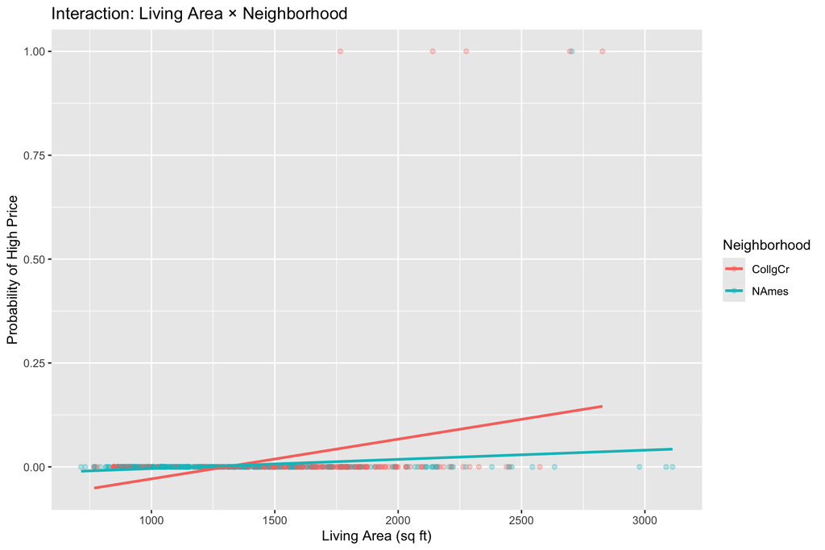

```r
# Visualize the interaction

ggplot(housing_two_nbhd, aes(x = Gr.Liv.Area,
                             y = HighPrice,
                             color = Neighborhood)) +
  geom_point(alpha = 0.3) +
  geom_smooth(method = "lm", se = FALSE) +
  labs(
    title = "Interaction: Living Area × Neighborhood",
    x = "Living Area (sq ft)",
    y = "Probability of High Price"
  )
```

# Part C: Linear Probability Model (LPM)

Now let’s model the probability of a house being high-priced using LPM.

```r
# Fit LPM with multiple predictors
lpm_model <- lm(HighPrice ~ Gr.Liv.Area + Overall.Qual + Year.Built +
                  CentralAir_Dummy + Garage.Cars,
                data = housing_clean)
summary(lpm_model)
```

```
Call:
lm(formula = HighPrice ~ Gr.Liv.Area + Overall.Qual + Year.Built +
    CentralAir_Dummy + Garage.Cars, data = housing_clean)

Residuals:
     Min       1Q   Median       3Q      Max
-0.57539 -0.09927 -0.03046  0.04582  0.88129

Coefficients:
                   Estimate Std. Error t value Pr(>|t|)
(Intercept)       3.862e-01  3.246e-01   1.190   0.2343
Gr.Liv.Area       8.617e-05  9.553e-06   9.021  < 2e-16 ***
Overall.Qual      4.659e-02  4.024e-03  11.579  < 2e-16 ***
Year.Built       -4.050e-04  1.727e-04  -2.345   0.0191 *
CentralAir_Dummy -4.010e-02  1.802e-02  -2.225   0.0261 *
Garage.Cars       4.524e-02  7.681e-03   5.891 4.31e-09 ***
---
Signif. codes:  0 '***' 0.001 '**' 0.01 '*' 0.05 '.' 0.1 ' ' 1

Residual standard error: 0.1935 on 2766 degrees of freedom
Multiple R-squared:  0.2415,    Adjusted R-squared:  0.2401
F-statistic: 176.1 on 5 and 2766 DF,  p-value: < 2.2e-16
```

### **Question 9**: Interpret the coefficient for Gr.Liv.Area. What does it represent in the context of LPM?

**Answer:** [The coefficient for Gr.Liv.Area is 0.000086, which means that in the Linear Probability Model, adding one extra square foot increases the probability of being a high-price home by about 0.0086%.

This number looks very small, but that’s normal, because one square foot is tiny and doesn’t change a home’s value on its own. The effect becomes meaningful only when living area increases by hundreds or thousands of square feet. For example, an extra 1,000 sq ft would raise the probability by about 8.6%. So overall, the model is telling us that bigger homes are more likely to be high-priced, but the impact comes from large increases in size, not one additional foot.]

### **Question 10**: Interpret the coefficient for Overall.Qual. How much does the probability of being high-price increase for each additional quality point?

**Answer:** [Overall.Qual 0.04659, so Coefficient = 0.0466 !Each extra point in Overall Quality raises the chance that a home is high-priced by about 4.66%.

That’s actually a pretty big jump.So if a home’s quality score goes from, say, 6 to 7, the probability of it being in the high-price group increases quite a lot. This effect is much stronger than the effect of adding a few extra square feet.

In other words, homes that are built better or finished better are much more likely to end up in the high-price category.]

## Checking for LPM Boundary Violations

```r
# Get predicted probabilities
housing_clean$lpm_pred <- predict(lpm_model)

# Check for violations
violations_below <- sum(housing_clean$lpm_pred < 0)
violations_above <- sum(housing_clean$lpm_pred > 1)

# Show summary statistics

violations_below
```

```
[1] 950
```

```r
violations_above
```

```
[1] 0
```

```r
total_violations <- violations_below + violations_above
percent_violations <- total_violations / nrow(housing_clean) * 100
percent_violations
```

```
[1] 34.27128
```

### **Question 11**: How many predictions fall outside the [0,1] bounds? What percentage is this?

**Answer:** [When I checked the LPM predictions, I found 950 predictions were below 0 and 0 were above 1. So the total number of invalid predictions is: 950 + 0 = 950

Since the dataset contains 2,772 homes, the percentage of invalid predictions is: 950 / 2772 × 100 = 34.27 %

So 34.27% of all predictions fall outside the valid [0,1] probability range.

This happens because the Linear Probability Model draws a straight line and cannot keep predictions between 0 and 1, especially when predictor values are very high or very low.

In simple words: the LPM gives many impossible probabilities, which makes it unreliable for this classification problem.]

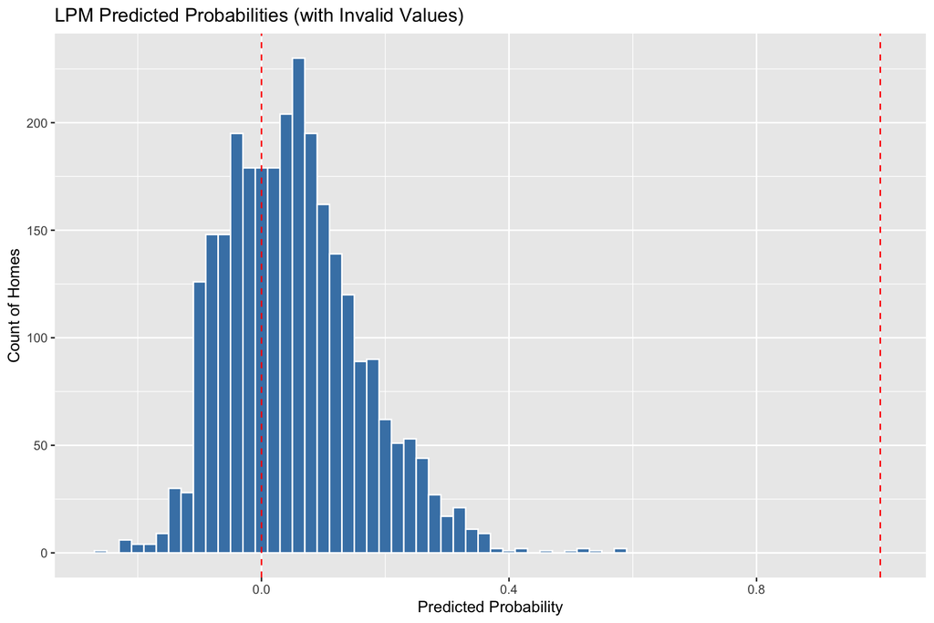

```r
# Visualize predictions including violations

housing_clean %>%
  ggplot(aes(x = lpm_pred)) +
  geom_histogram(binwidth = 0.02, fill = "steelblue", color = "white") +
  geom_vline(xintercept = 0, color = "red", linetype = "dashed") +
  geom_vline(xintercept = 1, color = "red", linetype = "dashed") +
  labs(
    title = "LPM Predicted Probabilities (with Invalid Values)",
    x = "Predicted Probability",
    y = "Count of Homes"
  )
```

### **Question 12**: Looking at your visualization, at what values of the predictors do we see boundary violations? Why is this problematic?

**Answer:** [From the Histogram, the boundary violations happen on the left end of the predicted values. It means that the model gives some probabilities that are below 0. They happen for houses the model thinks should be low price, like small or old house.

This is a problem because probabilities must always stay between 0 and 1. A negative probability doesn’t make sense in real life, so these predictions are not valid.

So, it can produce impossible probability values, which means we can’t fully trust it for classification.]

# Part D: Logistic Regression

Now let’s fit a logistic regression model with the same predictors.

```r
# Fit logistic regression
logit_model <- glm(HighPrice ~ Gr.Liv.Area + Overall.Qual + Year.Built +
                     CentralAir_Dummy + Garage.Cars,
                   data = housing_clean,
                   family = binomial)
summary(logit_model)
```

```
Call:
glm(formula = HighPrice ~ Gr.Liv.Area + Overall.Qual + Year.Built +
    CentralAir_Dummy + Garage.Cars, family = binomial, data = housing_clean)

Coefficients:
                   Estimate Std. Error z value Pr(>|z|)
(Intercept)      -7.339e+01  6.931e+02  -0.106   0.9157
Gr.Liv.Area       2.139e-03  3.219e-04   6.646 3.01e-11 ***
Overall.Qual      1.754e+00  1.829e-01   9.589  < 2e-16 ***
Year.Built        1.911e-02  1.076e-02   1.776   0.0758 .
CentralAir_Dummy  1.157e+01  6.928e+02   0.017   0.9867
Garage.Cars       1.270e+00  3.006e-01   4.223 2.41e-05 ***
---
Signif. codes:  0 '***' 0.001 '**' 0.01 '*' 0.05 '.' 0.1 ' ' 1

(Dispersion parameter for binomial family taken to be 1)

    Null deviance: 1132.1  on 2771  degrees of freedom
Residual deviance:  419.5  on 2766  degrees of freedom
AIC: 431.5

Number of Fisher Scoring iterations: 18
```

### **Question 13**: What is the sign of the coefficient for Gr.Liv.Area? What does this tell us about the relationship?

**Answer:** [The coefficient for Gr.Liv.Area is positive. This means that, holding all other variables constant, homes with larger above-ground living area have higher odds of being classified as high-price. In other words, as square footage increases, the probability that a home belongs to the high-price group increases.]

## Odds Ratios

```r
# Calculate odds ratios (exponentiate coefficients)

odds_ratios <- exp(coef(logit_model))
odds_ratios
```

```
     (Intercept)      Gr.Liv.Area     Overall.Qual       Year.Built
    1.337081e-32     1.002142e+00     5.778461e+00     1.019296e+00
CentralAir_Dummy      Garage.Cars
    1.056400e+05     3.559760e+00
```

```r
# Odds ratio specifically for Overall.Qual

exp(coef(logit_model)["Overall.Qual"])
```

```
Overall.Qual
    5.778461
```

### **Question 14**: Calculate and interpret the odds ratio for Overall.Qual. If quality increases by 1 point, how do the odds of being high-price change?

**Answer:** [The odds ratio for Overall.Qual is about 5.78. This means that if the overall quality score increases by 1 point, the odds of a house being high-price become 5.78 times larger.

In percentage terms: (5.78 − 1) × 100% = 478%

So, a 1-point increase in quality increases the odds of being a high-price home by about 478%.]

### **Question 15**: For a 500 sq ft increase in living area, how do the odds of being high-price change?

**Answer:** [The logistic regression coefficient for Gr.Liv.Area tells us the change in log-odds per 1 sq ft.

The model gives an odds ratio of 1.002142 for each additional 1 sq ft of living area.

coefficient = ln(1.002142) ≈ 0.00214

To find the effect of 500 sq ft, we scale the coefficient by 500 and again raise e to that value: Odds ratio for 500 sq ft =e^ (coefficient × 500)

Multiply inside: coefficient × 500 = 0.00214 × 500 = 1.07

Now apply the exponential: e^ 1.07 ≈ 2.91

(This is the same as compounding the 1-sq-ft odds ratio 500 times: 1.002142^ 500 ≈ 2.91)

Interpretation: A 500 sq ft increase in living area makes the odds of being a high-price home about 2.9 times higher, holding other variables constant.]

## Marginal Effects: AME vs MEM

```r
# Get fitted probabilities
housing_clean$logit_prob <- predict(logit_model, type = "response")

# Calculate marginal effect for each observation
# Formula: ME = β × p × (1-p)
beta_area <- coef(logit_model)["Gr.Liv.Area"]
housing_clean$ME_area <- beta_area * housing_clean$logit_prob * (1 - housing_clean$logit_prob)


# Average Marginal Effect (AME)
AME_area <- mean(housing_clean$ME_area)
AME_area
```

```
[1] 4.799145e-05
```

```r
# Marginal Effect at Means (MEM)
p_mean <- mean(housing_clean$logit_prob)
MEM_area <- beta_area * p_mean * (1 - p_mean)
MEM_area
```

```
 Gr.Liv.Area
0.0001053574
```

### **Question 16**: What is the Average Marginal Effect (AME) of Gr.Liv.Area? Interpret this in plain language.

**Answer:** [The AME is the average value of the marginal effect formula: MEi = β * pi(1 − pi) calculated across all homes.

In our model, the AME for Gr.Liv.Area is approximately: AME ≈ 0.000048

Interpretation: On average, increasing the living area by 1 sq ft increases the probability of a home being high-price by only 0.0048 percentage points. This is very small because 1 sq ft is a tiny change. Larger increases (like 500 sq ft) have much bigger effects.]

### **Question 17**: What is the Marginal Effect at Means (MEM)? How does it compare to AME and why are they different?

**Answer:** [To compute the MEM, we evaluate the marginal effect at the model’s average predicted probability, essentially, the effect for a “typical” home: MEM = β * pˉ(1−pˉ)

For our model:

MEM ≈ 0.000105 AME ≈ 0.000048

These values differ because logistic regression is nonlinear.

AME averages the marginal effect across all individual homes, each with its own prediction. MEM uses one single probability, the average, to compute the effect. Since marginal effects change at different probability levels, AME and MEM will not be the same. ]

### **Question 18**: Calculate the marginal effect for a specific house with p=0.5. How does this compare to AME and MEM?

**Answer:** [To calculate the marginal effect at p = 0.5, we use the formula: ME = β * p * (1 − p)

With β = 0.002139 and p = 0.5 : ME = 0.002139 * 0.5 * 0.5 = 0.002139 * 0.25 = 0.000535

Comparison: This marginal effect (0.000535) is larger than the AME (~0.000048) and larger than the MEM (~0.000105). This happens because p = 0.5 is where logistic curves are steepest, so the model is most sensitive to changes in living area at this probability level.]

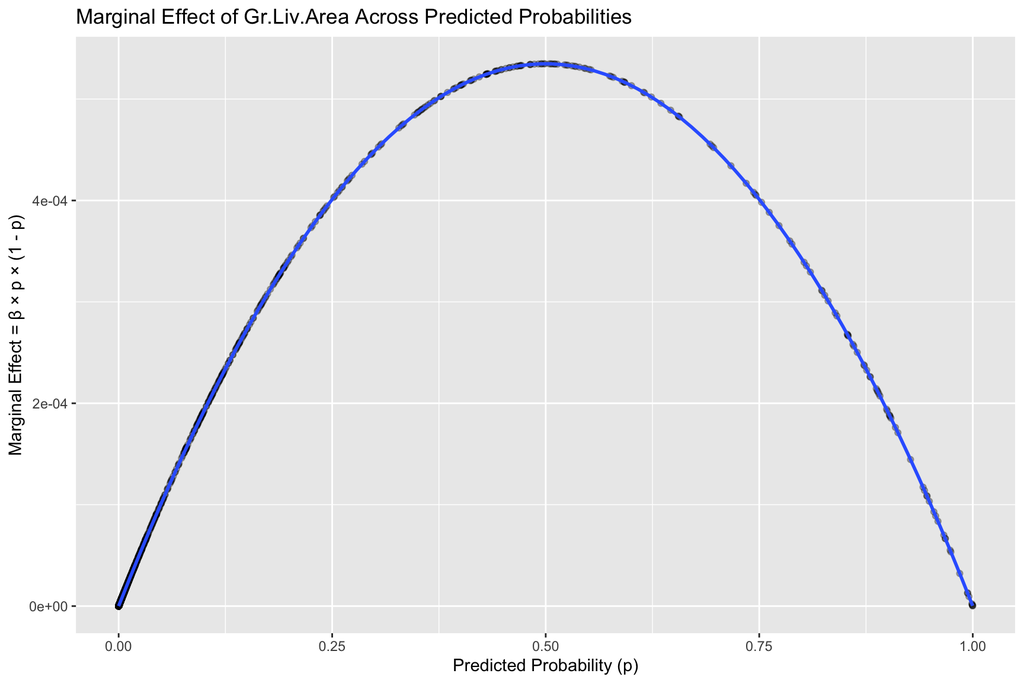

```r
# Visualize how marginal effect varies

library(ggplot2)

ggplot(housing_clean, aes(x = logit_prob, y = ME_area)) +
  geom_point(alpha = 0.3) +
  geom_smooth(method = "loess", se = FALSE) +
  labs(
    title = "Marginal Effect of Gr.Liv.Area Across Predicted Probabilities",
    x = "Predicted Probability (p)",
    y = "Marginal Effect = β × p × (1 - p)"
  )
```

# Part E: Model Comparison

## Side-by-Side Predictions

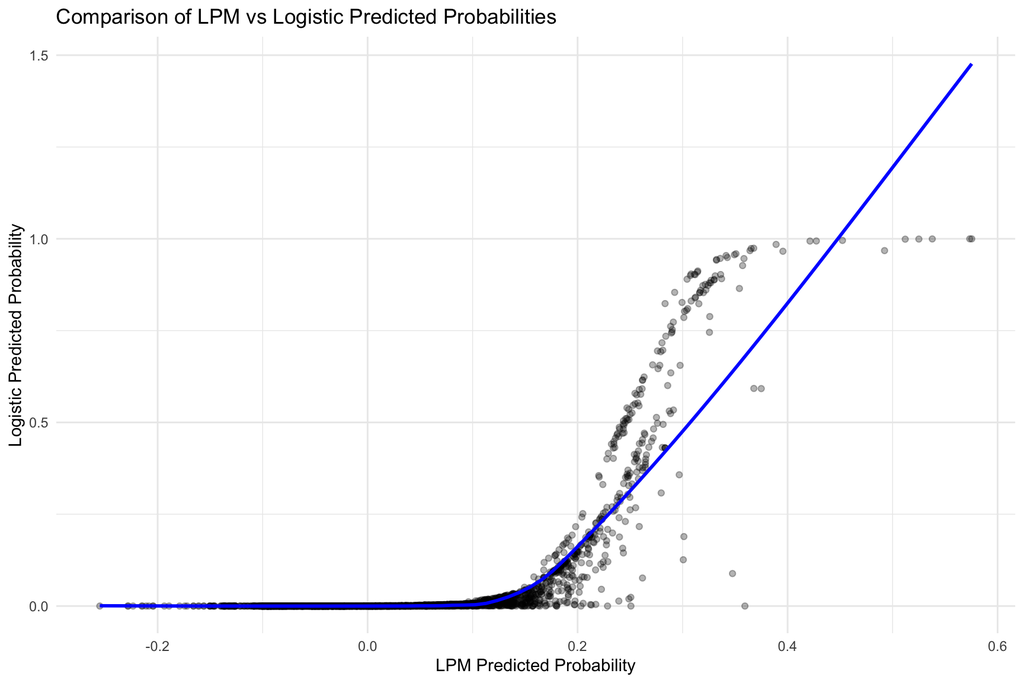

```r
# Compare predicted probabilities

ggplot(housing_clean, aes(x = lpm_pred, y = logit_prob)) +
  geom_point(alpha = 0.3) +
  geom_smooth(method = "loess", se = FALSE, color = "blue") +
  labs(
    title = "Comparison of LPM vs Logistic Predicted Probabilities",
    x = "LPM Predicted Probability",
    y = "Logistic Predicted Probability"
  ) +
  theme_minimal()
```

### **Question 19**: Create a scatter plot comparing LPM and Logistic predictions. Where do they differ most?

**Answer:** [From the plot, the two models are pretty similar only in the middle, around the average predicted values. But the moment you move toward the edges, they start to disagree a lot.

On the left side, the LPM gives negative probabilities, which makes no sense in real life. Logistic Regression keeps everything correctly near zero. On the right side, the LPM keeps going upward like a straight line, while Logistic Regression slows down and stays between 0 and 1 like a proper probability model.

```r
# Calculate correlation and RMSE for both model
# Correlation with actual HighPrice

cor_lpm  <- cor(housing_clean$HighPrice, housing_clean$lpm_pred)
cor_logit <- cor(housing_clean$HighPrice, housing_clean$logit_prob)

cor_lpm
```

```
[1] 0.4914323
```

```r
cor_logit
```

```
[1] 0.7587732
```

```r
# RMSE function
rmse <- function(actual, predicted) {
  sqrt(mean((actual - predicted)^2))
}

rmse_lpm <- rmse(housing_clean$HighPrice, housing_clean$lpm_pred)
rmse_logit <- rmse(housing_clean$HighPrice, housing_clean$logit_prob)

rmse_lpm
```

```
[1] 0.1932755
```

```r
rmse_logit
```

```
[1] 0.1446243
```

### **Question 20**: Which model has better correlation with the actual outcome? Better RMSE?

**Answer:** [The logistic regression model performs better than the LPM on both measures.

Correlation: The LPM has a correlation of 0.49, while the logistic model reaches 0.76. This means the logistic model’s predictions match what actually happened much better than the LPM’s predictions.

RMSE: The LPM’s RMSE is 0.193, and the logistic model’s RMSE is lower at 0.145. A lower RMSE means fewer and smaller prediction errors, which again shows logistic regression is more accurate.

Overall, Logistic regression clearly gives more reliable probability predictions, so it is the better model for identifying high-price homes.]

# Part F: Classification and Threshold Selection

## Default Threshold (0.5)

```r
# Classify using 0.5 threshold
housing_clean$logit_class_50 <- ifelse(housing_clean$logit_prob > 0.5, 1, 0)

# Create confusion matrix
conf_matrix_50 <- table(
  Predicted = factor(housing_clean$logit_class_50, levels = c("1", "0")),
  Actual    = factor(housing_clean$HighPrice,      levels = c("1", "0"))
)

conf_matrix_50
```

```
         Actual
Predicted    1    0
        1   82   21
        0   62 2607
```

```r
# Calculate metrics
# Extract TP, FP, FN, TN
TP <- conf_matrix_50[1,1]
FP <- conf_matrix_50[1,2]
FN <- conf_matrix_50[2,1]
TN <- conf_matrix_50[2,2]

# Metrics
accuracy  <- (TP + TN) / sum(conf_matrix_50)
precision <- TP / (TP + FP)
recall    <- TP / (TP + FN)

accuracy
```

```
[1] 0.9700577
```

```r
precision
```

```
[1] 0.7961165
```

```r
recall
```

```
[1] 0.5694444
```

### **Question 21**: Using threshold=0.5, what is the accuracy? Precision? Recall?

**Answer:** [Using the 0.5 threshold, the confusion matrix gives:

True Positives (TP): 82 False Positives (FP): 21 False Negatives (FN): 62 True Negatives (TN): 2607

From these values:

Accuracy ≈ 97.0% About 97% of all homes are correctly classified by the model.

Precision ≈ 79.6% When the model predicts a home is high-price, it is right about 80% of the time.

Recall ≈ 56.9% The model catches about 57% of all actual high-price homes.

Overall, the model is very accurate and precise, but its recall is lower, meaning it still misses some high-price homes.]

### **Question 22**: In this context, what is the cost of a False Positive vs False Negative? Which error is more serious for a real estate agent?

**Answer:** [A False Positive happens when the model says a house is high-price but it’s actually not. For an agent, this mainly means wasted time, preparing high-end marketing, targeting luxury buyers, and putting extra effort into a property that won’t bring a big commission. Annoying, but not financially painful.

A False Negative happens when the model says a house is not high-price but it really is. This is a much bigger problem. The agent might treat a luxury home like a regular one, miss the right buyers, or even lose the chance to list it. That’s a real loss in potential commission, thousands of dollars gone.

So the more serious mistake is a False Negative, because it directly costs the agent money, not just time.]

## Optimal Threshold Selection

```r
# Function to calculate metrics at any threshold
calc_metrics <- function(actual, predicted_prob, threshold) {

  # Classify using this threshold
  predicted_class <- ifelse(predicted_prob > threshold, 1, 0)

  # Confusion matrix with TP at [1,1]
  cm <- table(
    Predicted = factor(predicted_class, levels = c("1", "0")),
    Actual    = factor(actual,          levels = c("1", "0"))
  )

  # Extract TP, FP, FN, TN
  TP <- cm[1, 1]
  FP <- cm[1, 2]
  FN <- cm[2, 1]
  TN <- cm[2, 2]

  # Metrics
  accuracy    <- (TP + TN) / sum(cm)
  precision   <- ifelse(TP + FP > 0, TP / (TP + FP), 0)
  recall      <- ifelse(TP + FN > 0, TP / (TP + FN), 0)
  specificity <- TN / (TN + FP)
f1_score <- 2 * (precision * recall) / (precision + recall)


  data.frame(
    threshold = threshold,
    accuracy = accuracy,
    precision = precision,
    recall = recall,
    specificity = specificity,
    f1_score = f1_score
  )
}


# Test multiple thresholds

thresholds <- seq(0.01, 0.99, by = 0.01)

metrics_df <- do.call(rbind, lapply(thresholds, function(t) {
  calc_metrics(housing_clean$HighPrice, housing_clean$logit_prob, t)
}))

# Find threshold that maximizes F1-score

best_threshold <- metrics_df$threshold[which.max(metrics_df$f1_score)]
best_threshold
```

```
[1] 0.44
```

### **Question 23**: What is the optimal threshold for maximizing F1-score? How does this compare to the default 0.5?

**Answer:** [The optimal threshold that maximizes the F1-score is 0.44.

This is lower than the default threshold of 0.5. The reason is that with a 0.5 cutoff, the model misses many high-price homes (low recall). When we lower the threshold to 0.44, the model catches more true positives without increasing false positives too much. This improves the balance between precision and recall, which is why the F1-score is highest at 0.44.

In short: 0.5 threshold : too strict → misses many high-price homes 0.44 threshold : better balance → highest F1-score

So, 0.44 performs better for this classification task.]

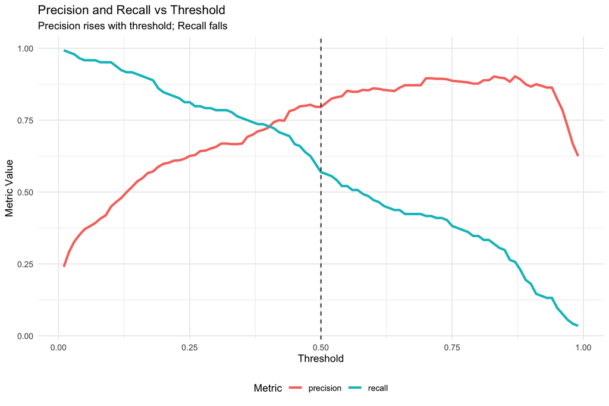

```r
# Plot metrics vs threshold
# Extract only precision and recall for plotting
precision_recall_df <- metrics_df %>%
  select(threshold, precision, recall) %>%
  pivot_longer(
    cols = c(precision, recall),
    names_to = "metric",
    values_to = "value"
  )

# Plot Precision and Recall vs Threshold
ggplot(precision_recall_df, aes(x = threshold, y = value, color = metric)) +
  geom_line(size = 1.2) +
  geom_vline(xintercept = 0.5, linetype = "dashed", color = "black") +
  labs(
    title = "Precision and Recall vs Threshold",
    subtitle = "Precision rises with threshold; Recall falls",
    x = "Threshold",
    y = "Metric Value",
    color = "Metric"
  ) +
  theme_minimal() +
  theme(legend.position = "bottom")
```

### **Question 24**: Create a plot showing how Precision and Recall change with the threshold. Describe the trade-off.

**Answer:** [As we increase the classification threshold, Precision goes up while Recall goes down.

At low thresholds, the model predicts “high-price” more often. → It catches almost all actual high-price homes (high Recall) but also makes many mistakes (lower Precision).

At high thresholds, the model only predicts “high-price” when it is very confident. → Fewer mistakes (high Precision) but it misses many real high-price homes (low Recall).

This inverse movement is the classic precision–recall trade-off: You can’t raise one without lowering the other. this plot correctly shows this pattern, the Precision curve rises as the threshold increases, and the Recall curve falls.]

## Cost-Based Threshold

Suppose a real estate agent faces these costs: - **False Negative** (miss a high-price home): Lost commission of $6,000 - **False Positive** (waste time on normal home): Lost opportunity cost of $300

```r
# Calculate expected cost for each threshold
cost_fn <- 6000
cost_fp <- 300


metrics_df <- metrics_df %>%
  mutate(
    total_highprice = sum(housing_clean$HighPrice),
    total_non_highprice = sum(1 - housing_clean$HighPrice),
    fn_count = total_highprice * (1 - recall),
    fp_count = total_non_highprice * (1 - specificity),
    expected_cost = fn_count * cost_fn + fp_count * cost_fp
  )

# Find cost-minimizing threshold

optimal_cost_idx <- which.min(metrics_df$expected_cost)
optimal_cost_threshold <- metrics_df$threshold[optimal_cost_idx]
optimal_cost <- metrics_df$expected_cost[optimal_cost_idx]

optimal_cost_threshold
```

```
[1] 0.1
```

```r
optimal_cost
```

```
[1] 92400
```

### **Question 25**: What is the optimal threshold when considering these costs? How does it compare to the F1-maximizing threshold?

**Answer:** [Using the cost-based approach (False Negative = $6,000, False Positive = $300), the optimal threshold is 0.10, with an expected cost of about $92,400.

This is lower than the F1-maximizing threshold of 0.44. With such expensive False Negatives (missing a high-price home), it is better for the agent to use a more aggressive threshold (0.10), catch more potential high-price homes, and accept more False Positives.

In short:

Threshold 0.44 (F1-optimal): Best balance between precision and recall. Threshold 0.10 (cost-optimal): Best from a money perspective, because it reduces the total expected loss from missed high-price homes, even though it creates more extra work on normal homes.]

### **Question 26**: Why would the cost-based threshold be different from the F1-maximizing threshold?

**Answer:** [The F1-maximizing threshold tries to balance precision and recall, treating false positives and false negatives as equally important. But in real life the costs aren’t equal. For a real estate agent, missing a high-price home (false negative) could mean losing a large commission, while mistakenly flagging a normal home (false positive) is just a small inconvenience.

Because false negatives are much more expensive, the cost-based threshold shifts lower. The model becomes more aggressive in predicting high-price homes so the agent doesn’t miss valuable opportunities, even if that means more false alarms.

In short: the cost-based threshold focuses on avoiding the most expensive mistakes, not on balancing precision and recall like the F1 score does.]

# Part G: Prediction on New Data

```r
# Create train-test split (75-25)

set.seed(123)
n <- nrow(housing_clean)
train_index <- sample(1:n, size = 0.75 * n)

train_data <- housing_clean[train_index, ]
test_data  <- housing_clean[-train_index, ]


# Fit models on training data

logit_model_train <- glm(
  HighPrice ~ Gr.Liv.Area + Overall.Qual + Year.Built +
    CentralAir_Dummy + Garage.Cars,
  data = train_data,
  family = binomial
)


# Predict on test data

test_prob <- predict(logit_model_train, newdata = test_data, type = "response")
test_pred <- ifelse(test_prob > 0.5, 1, 0)

# Test accuracy
test_accuracy <- mean(test_pred == test_data$HighPrice)
test_accuracy
```

```
[1] 0.969697
```

```r
# Training accuracy
train_prob <- predict(logit_model_train, newdata = train_data, type = "response")
train_pred <- ifelse(train_prob > 0.5, 1, 0)
train_accuracy <- mean(train_pred == train_data$HighPrice)
train_accuracy
```

```
[1] 0.97114
```

### **Question 27**: What is the test set accuracy for logistic regression? How does it compare to training accuracy?

**Answer:** [Test set accuracy measures how well the logistic regression model predicts outcomes on new, unseen data.

The test set accuracy is 0.970. The training accuracy is 0.971.

These two values are almost the same, which means the logistic regression model generalizes well. The model performs just as accurately on unseen data as it does on the data it was trained on. When the training and test accuracies are this close, it indicates no meaningful overfitting: the model is not memorizing the training data, and its predictions remain stable when applied to new homes. This suggests the model is appropriately specified and captures the main relationships without being overly complex.]

```r
# Prediction for a specific new house

new_house <- data.frame(
  Gr.Liv.Area = 2000,
  Overall.Qual = 8,
  Year.Built = 2005,
  CentralAir_Dummy = 1,
  Garage.Cars = 2
)

pred_prob_new <- predict(logit_model_train, newdata = new_house, type = "response")
pred_prob_new
```

```
         1
0.06886741
```

### **Question 28**: For a house with 2000 sq ft living area, quality rating of 8, built in 2005, with central air and a 2-car garage, what is the predicted probability of being high-price?

**Answer:** [The predicted probability that this house is high-price is 0.069. This means the model estimates about a 6.9% chance that the home falls into the high-price category given its size, quality, year built, central air, and garage size.]

```r
# Create confusion matrix for test set
# Test confusion matrix
test_conf_matrix <- table(
  Predicted = factor(test_pred, levels = c(1, 0)),
  Actual    = factor(test_data$HighPrice, levels = c(1, 0))
)
test_conf_matrix
```

```
         Actual
Predicted   1   0
        1  19  10
        0  11 653
```

```r
# Training confusion matrix
train_conf_matrix <- table(
  Predicted = factor(train_pred, levels = c(1, 0)),
  Actual    = factor(train_data$HighPrice, levels = c(1, 0))
)
train_conf_matrix
```

```
         Actual
Predicted    1    0
        1   72   18
        0   42 1947
```

### **Question 29**: Compare the confusion matrix on test data vs training data. Are the results similar?

**Answer:** [Yes, the test and training confusion matrices are very similar.

On the test set, the model correctly identifies 19 high-price homes and 653 non–high-price homes, with relatively few mistakes (10 false positives and 11 false negatives).

On the training set, it correctly identifies 72 high-price homes and 1947 non–high-price homes, with a similar pattern of errors (18 false positives and 42 false negatives).

The ratios of correct vs incorrect predictions are consistent across both datasets. This indicates that the model is stable and performs similarly on unseen data as it does on training data.

Because the confusion matrices follow the same pattern, the model shows no evidence of overfitting.]

# Part H: Summary and Conclusions

### **Question 30**: Based on your analysis, which three factors are most important in predicting high-price homes?

**Answer:** [Based on the logistic regression results, the three most important predictors of high-price homes are Overall Quality, Above-Ground Living Area (Gr.Liv.Area), and Garage Capacity (Garage.Cars).

All three predictors have strong statistical evidence (large z-values and very small p-values), and all have positive coefficients, meaning they increase the probability of a home being high-price.

Living Area also plays a significant role. Its coefficient (0.0021) is small because it is measured per square foot, but it has a very strong z-value and p-value. The marginal effect helps make this more intuitive: every extra square foot slightly increases the probability of being high-price, and realistic changes (e.g. +500 sq ft) lead to a large and meaningful increase in probability.

In overall, the combination of positive coefficients, strong significance, large odds ratios, and practical marginal effects shows that quality, size, and garage capacity are the three most important predictors of high-price homes.]

### **Question 31**: Would you recommend using LPM or Logistic Regression for this problem? Why?

**Answer:** [I would recommend using Logistic Regression instead of the Linear Probability Model (LPM).

Logistic Regression is more appropriate for this problem because the outcome (HighPrice) is a binary variable. Logistic Regression keeps all predicted values between 0 and 1, models probability in a realistic S-shaped curve, and provides meaningful tools such as z-values, p-values, odds ratios, and marginal effects.

In contrast, LPM often gives probabilities outside the 0–1 range and does not handle the relationship between predictors and a binary outcome as accurately. So, logistic Regression is more reliable and statistically correct for predicting high-price homes.]

### **Question 32**: If you were a real estate agent, how would you use this model? What threshold would you choose and why?

**Answer:** [If I were a real estate agent, I would use the logistic regression model to help me guess which homes are likely to be high-price. This would guide me on which homes deserve extra attention, better marketing, and more effort. Instead of guessing, I would look at the model’s predicted probability for every new home.

Because high-price homes are rare and missing one could cost a lot of money in lost commission, I would choose a lower threshold, around 0.10. A lower threshold makes the model more willing to say “this might be high-price,” which helps me avoid missing valuable homes. Even though this creates more false alarms, they only waste a little time. Missing a real high-price home is much more expensive.

In short: I would use logistic regression to score each home. I would choose a 0.10 threshold to catch more potential high-price homes. This helps me protect my income and not miss valuable listings.]

### **Question 33**: What are the limitations of this model? What additional variables or improvements would you suggest?

**Answer:** [This model works well, but it has some limits. It only uses a few variables, so it doesn’t capture everything that makes a home expensive. Real estate prices depend on many things, like neighborhood quality, lot size, upgrades, schools, and even how the house looks. Because we don’t include these extra details, the model can miss important information.

Also, the model is based on the 95th percentile cutoff, which is just one way of defining “high-price,” and a different cutoff could give slightly different results.

To make the model better, I would add more information about the homes, things like lot size, number of bathrooms, renovation history, basement finish, or school ratings.

I would also include more neighborhood features. Another improvement could be trying more flexible models (like random forests) to see if they capture patterns better.

In short, the model is useful, but it would improve a lot if we added more details about each home and tried a few stronger prediction methods.]

# Submission Checklist

Before submitting, ensure you have:

- Answered all 33 questions with complete explanations
- All code chunks execute without errors
- Created all requested visualizations
- Interpreted coefficients in context
- Calculated marginal effects correctly
- Compared LPM vs Logistic thoroughly
- Evaluated classification performance
- Selected and justified optimal threshold
- Document renders to HTML successfully

**Good luck with your analysis!**

#Disclosure (LLM use): I used ChatGPT (GPT-5) to assist with writing and suggest coding and some interpretation templates. All outputs were reviewed and verified.